# Disentangling the spinal mechanisms of illusory heat and burning sensations in the Thermal Grill Illusion

Alexandra G. Mitchell<sup>1</sup>, Jesper Fischer Ehmsen<sup>1</sup>, Daniel Elmstrom Christensen<sup>1</sup>, Anna Villaume Stuckert<sup>2</sup>, Patrick Haggard<sup>3</sup>, Francesca Fardo<sup>1,4</sup>

<sup>1</sup>Center of Functionally Integrative Neuroscience, Department of Clinical Medicine, Aarhus University, Denmark

<sup>2</sup>Department of Neuroscience, Copenhagen University, Denmark

<sup>3</sup>Institute of Cognitive Neuroscience, University College London, United Kingdom

<sup>4</sup>Danish Pain Research Center, Department of Clinical Medicine, Aarhus University, Denmark

Corresponding authors: Alexandra G. Mitchell (agmitchell@cfin.au.dk) and Francesca Fardo (francesca@cfin.au.dk)

# Abstract

# Introduction

The thermal grill illusion (TGI) is a perceptual phenomenon that challenges conventional understanding of pain perception. It is a sensation of burning heat or pain when harmless cold and warm temperatures are applied to the skin simultaneously (Craig and Bushnell 1994; Craig et al. 1996). Despite cold and warm temperatures being individually innocuous, their combination produces a contradictory burning sensation, even so the temperatures are insufficient to activate peripheral nociceptors. The generation of this illusion is thus attributed to central nervous system mechanisms (Craig and Bushnell 1994; Fardo et al. 2020). Recent studies have highlighted the involvement of the spinal cord as an initial site contributing to the TGI (Fardo, Finnerup, and Haggard 2018; Harper and Hollins 2017). However, the precise mechanisms underpinning integration of cold and warm thermal afferents in the spinal cord, alongside those responsible for the distinctive burning quality to this illusion, are yet to be elucidated.

The TGI is often described as encompassing two distinct perceptual components - an illusion of heat and an illusion of pain (Defrin et al. 2008; Fardo et al. 2020). The illusion of heat, also known as synthetic heat (Fruhstorfer, Harju, and Lindblom 2003; Green 1977, 2002, 2004), refers to non-painful heat sensations evoked by the thermal grill (Defrin et al. 2008; Kern et al. 2008; 2008; Bouhassira et al. 2005; Adam et al. 2014). The illusion of pain, which is the most recognised aspect of the TGI, is the distinctive burning sensation that accompanies the simultaneous presentation of cold and warm stimuli (Craig and Bushnell 1994; 1996; Bach et al. 2011). The hallmark of both illusory components is a qualitative change in perception when the cold and warm stimuli are applied concurrently, compared to when they are presented individually. Historically, the thermosensory and painful components of the TGI were explained by distinct spinal and supraspinal mechanisms, respectively. The enhanced perception of heat in TGI was explained by a spinal inhibitory mechanism, drawing from observations in an animal model where simultaneous application of cold and warm temperatures reduced the activity of cold-specific spinal neurons compared to when cold was applied alone (Craig and Bushnell 1994). Instead, the illusory pain component was ascribed to a disinhibition mechanism at the level of the thalamus, primarily based on the observations of unremitting pain following thalamic lesions (Craig and Bushnell 1994; 1998).

Recent human studies on TGI provided differing interpretations of the spinal or supraspinal origin of the illusion. Two studies posited that the illusory pain component of the TGI depends uniquely on supraspinal mechanisms. This interpretation was based on the observed modulation of the illusion in accordance with a spatiotopic rather than somatotopic representation of the body (Marotta, Ferrè, and Haggard 2015). Further, the illusion remained unaltered during concomitant tactile stimulation, suggesting ineffectiveness of tactile gating - a spinally-mediated process involving inhibition of nociceptive activity by concurrent somatosensory activity (Ferrè et al. 2018). Counter to this perspective, other research endorsed a spinal contribution to the TGI. These studies demonstrated that the illusion varied depending on whether cold and warm stimuli were applied to dermatomes mapped either onto adjacent or non-adjacent spinal segments (Fardo, Finnerup, and Haggard 2018). Participants perceived the stimulation more veridically, consistently with a reduction in TGI perception, when warm or cold stimuli mapped on segmental locations that were apart along the spinal cord, corroborating the hypothesis that the spinal cord is an initial site of thermosensory integration underlying TGI. Further support for spinal mechanisms comes from research demonstrating that both noxious heat and the TGI were comparably reduced by conditioned pain modulation in humans. This suggests a similar influence of descending modulation, irrespective of whether the painful sensation was triggered by potentially harmful (noxious) or harmless (TGI) stimuli (Harper and Hollins 2017). These findings collectively challenge a purely supraspinal hypothesis of the painful component of the TGI and indicate the relevance of spinal mechanisms in the manifestation of both illusory heat and pain.

In this paper our objective was twofold. Firstly, we directly investigated the hypothesis that thermosensory and burning components of the TGI experience are mediated by spinal mechanisms in humans, by manipulating the location of the stimuli within and across dermatomes. Cold and warm stimuli were presented at a fixed distance on the skin, but depending on their longitudinal or tangential orientation on the arm, they elicited differing neural activity in the spinal cord. Our assumption was that cold and warm-related neural activity in the spinal cord was more focal (i.e., within the same spinal segments or within a few adjacent segments), when the stimuli were presented within the same dermatome, while more widespread, when the stimuli mapped on non-adjacent spinal segments (i.e., possibly 2 to 4 segments apart). Our past work using a similar manipulation involved measuring the experience of the TGI using a temperature matching task (Fardo, Finnerup, and Haggard 2018), which provides a composite measure of TGI perception, reflecting both thermosensory and painful components. Here, to probe possible distinctions between the two qualitative components of the TGI, we measured subjective indices of TGI perception using three independent visual analog scale (VAS) ratings of perceived cold, warm and burning sensations. Secondly, we investigated spatial order effects associated with the integration of cold and warm sensory information at the dermatome (skin) and segmental (i.,e., spine) levels. At the dermatome level, we used body-related coordinates to define proximal (towards the elbow) and distal (towards the wrist) locations. At the spinal level, we used segment-related coordinates to define more rostral (towards the head) and more caudal (towards the lower back) locations. Given the organisation of the spinal cord along a rostral-caudal axis, where each dermatome is represented across multiple spinal segments through the Lissauer tract (Kerr 1975; Lamotte 1977; Wall, Lidierth, and Hillman 1999), this study aimed to glean indirect insights into the spinal mechanisms underpinning thermosensory integration and the generation of the TGI.

# Results and discussion

The Thermal Grill Illusion (TGI) is characterised by two key phenomena: thermosensory enhancement and illusory pain. Thermosensory enhancement refers to an amplified perception of heat or cold when cold and warm stimuli are simultaneously applied, as opposed to when each stimulus is presented individually or paired with a neutral temperature. Notably, the majority of individuals experience an intensification of heat rather than cold (Fardo et al. 2020). Illusory pain, on the other hand, denotes the perception of a burning sensation elicited by the pairing of warm and cold stimuli, an experience that is largely absent or significantly diminished when each stimulus is presented alone or combined with a neutral temperature. Thus, indicators of a stronger TGI are reduced cold ratings, coupled with heightened warm and burning ratings.

To investigate thermosensory and burning components of the TGI, participants received pairs of temperatures on their forearms and were asked to quantify the levels of cold, warmth, and burning they experienced during each stimulation. These stimuli consisted of either cold-warm pairs (TGI stimuli), which potentially evoked an illusion of heat and pain, or control stimuli that involved pairing a cold or a warm stimulus of identical temperature as in the TGI condition with a baseline temperature of 30°C (non-TGI stimuli). All stimulation pairs were presented at a fixed distance on the skin, either within the same dermatome or across dermatomes that mapped onto non-adjacent spinal segments. For each stimulation, participants reported their ratings using three sequential VAS scales ranging from 0, indicating the lack of a sensation, to 100, indicating an extreme sensation. For each instance of stimulation, participants were guided to focus their reporting on the sensations originating from a specific thermode. While the participants were unaware, this location corresponded to either the colder stimulus (Exp. 1) or the warmer stimulus (Exp. 2) of the paired temperatures. VAS ratings were analysed using zero-inflated beta regressions.

## Thermosensory and burning components of TGI perception are spinally mediated

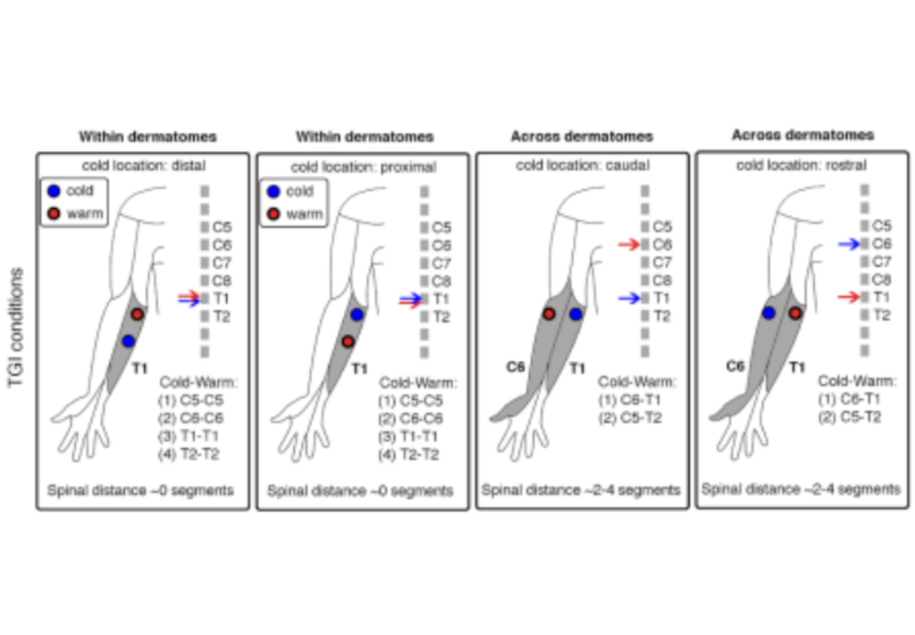

Figure 1) Four experimental conditions depicting an exemplar cold and warm thermode placement within and across dermatomes. Within dermatomes, the relative location of the cold thermode was proximal or distal. Across dermatomes, the relative location of the corresponding spinal segments was rostral or caudal.

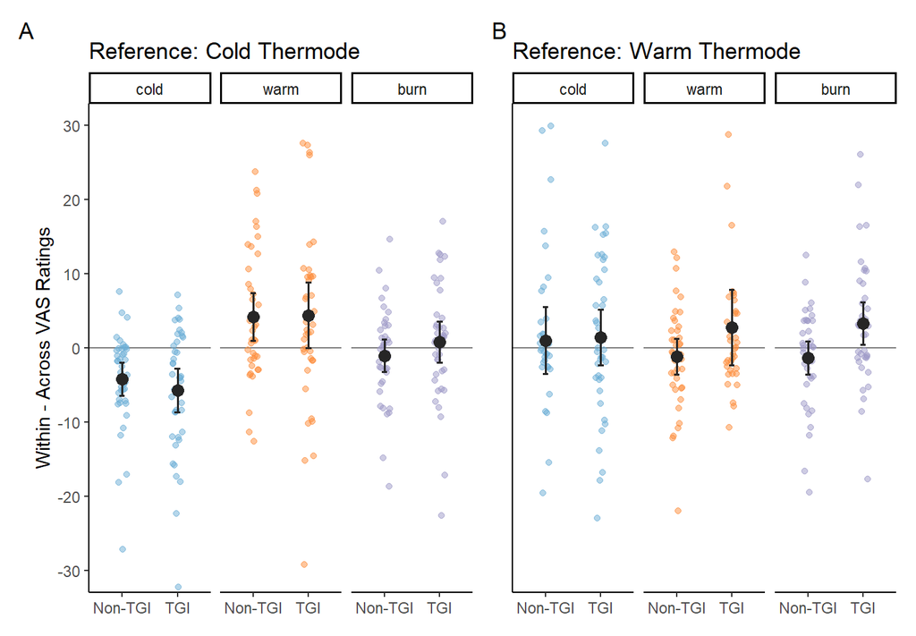

Figure 2) Difference in VAS ratings between within and across dermatome conditions for each type of stimulation (Non-TGI and TGI) in each VAS rating quality (cold, warm and burning). Positive values represent higher ratings within dermatomes, negative values represent higher ratings across dermatomes. Small dots are individual subject means, large dots are population means for each condition and error bars are 95% confidence intervals. A) first experiment with the cold thermode as the reference, and B second experiment with the warm thermode as referece.

When rating the warm thermode (Exp. 2, Fig. 2B), participants reported markedly enhanced burning sensations for TGI, but not non-TGI, stimuli applied within a dermatome compared to across dermatomes (stimulation by dermatome interaction: $\beta$ = 0.21, p < .001). However, we did not observe modulation of cold (stimulation by dermatome interaction: n$\beta$ = 0.08, p = 0.28; dermatome main effect: $\beta$ = 0.01, p = 0.83) or warm ratings (stimulation by dermatome interaction: $\beta$ = 0.07, p = 0.16; dermatome main effect: $\beta$ = -0.04, p = 0.28) according to the within-across dermatome manipulation. Overall, these results indicated that when participants assessed the warm thermode, the greatest modulation in TGI perception was related to burning sensations, with within-dermatome TGI stimuli perceived as the most burning.

The findings suggest that the thermosensory quality of the reference thermode (cold or warm) showed differential sensitivity to thermosensory and painful aspects of the TGI experience, and collectively suggested that both qualitative components of the illusion are modulated at the spinal cord level. This interpretation is consistent with a previous study using a similar dermatome manipulation, but a distinct method to quantify TGI perception (Fardo, Finnerup, and Haggard 2018), as well as another study showing modulation of heat and pain ratings of TGI stimuli by conditioned pain modulation (Harper and Hollins 2017). All together these results support the role of spinal processes in the generation of distinct perceptual aspects of the TGI, and highlight the importance of the reference stimulus when assessing thermosensory and burning components of TGI perception.

## Proximodistal bias in cold perception

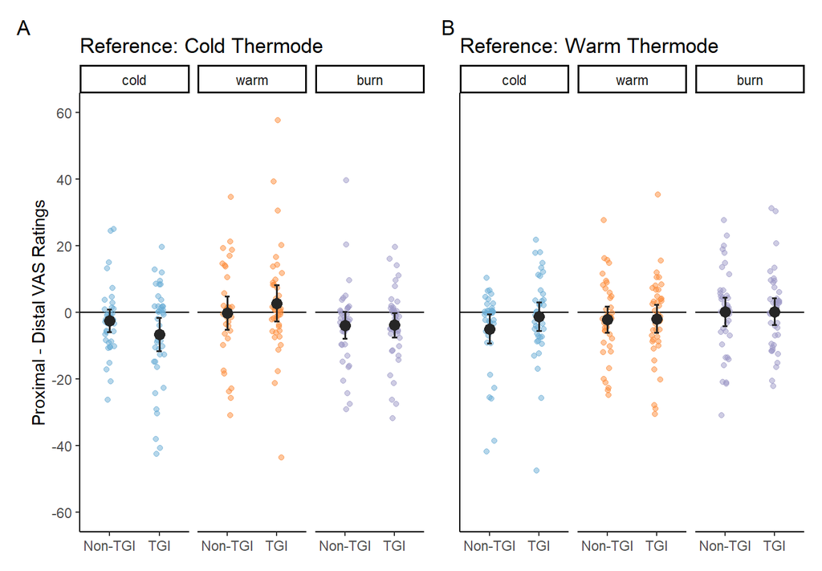

Figure 3) Difference in VAS ratings between the proximal and distal location of the reference thermode in the within dermatome condition and by stimulation type (Non-TGI, TGI) for all VAS rating types (cold, warm, burn). A, experiment with the cold thermode as reference, and B with the warm thermode as reference. Small points show data from each participant, large dots are means across trials for each condition, and error bars show 95% confidence intervals.

## Directional effects in inter-segmental sensory integration

A main objective of this study was assessing spatial order effects along the rostrocaudal axis at the spinal level. We delivered an equal number of trials in which the cold stimulus was applied on a dermatome that mapped more rostrally or caudally compared to the warm or neutral stimuli, in the across dermatome condition. When rating either the cold thermode (Exp. 1, Fig. 4A) or the warm thermode (Exp.2, Fig. 4B), participants reported a reduced subjective experience of cold, alongside an enhanced perception of warmth when the cold thermode was applied on a dermatome that mapped onto a more caudal segment. In Exp. 1, the modulation of thermosensory ratings corresponded to significant rostralcaudal main effects for both cold ratings (stimulation by rostrocaudal location interaction: $\beta$ = -0.10, p = 0.19; rostrocaudal main effect: $\beta$ = -0.15, p < .01), and warm ratings (stimulation by rostrocaudal location interaction: $\beta$ = 0.06, p = 0.65; rostrocaudal main effect: $\beta$ = 0.21, p < .05 ). In Exp. 2, the modulation of cold ratings was specific for TGI stimuli (stimulation by rostrocaudal location interaction: $\beta$ = -0.23, p < .05 ), while the modulation of warm ratings was significant irrespective of stimulation type (stimulation by rostrocaudal interaction: $\beta$ = 0.01, p = 0.94; rostrocaudal main effect: $\beta$ = 0.19, p < .001). Similarly to warm ratings, we showed a modulation of burning ratings depending on the rostrocaudal mapping of cold-related activity irrespective of stimulation type in Exp. 2 (stimulation by rostrocaudal location: $\beta$ = -0.14, p = 0.1; rostrocaudal main effect: $\beta$ = 0.17, p < .01). The results indicated a notably enhanced TGI effect when the cold stimulus induced more caudal activity within the spinal cord. While reduced cold perception was more specific for TGI stimuli, participants reported enhanced warm and burning perception irrespective of stimulation type. Overall these effects are in line with the interpretation that the reference stimulation is a crucial factor in assessing thermosensory and burning components of TGI perception.

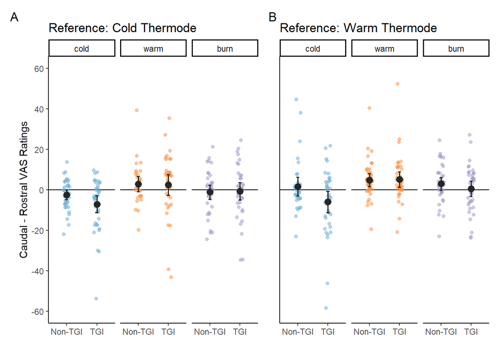

Figure 4) Difference in VAS ratings between the Caudal and Rostral dermatome conditions and the stimulation type (Non-TGI, TGI) for all VAS rating types (Cold, warm, Burning). A, first experiment with the cold thermode as the reference, and B with the warm thermode as referce. Small points show data from each participant, large dots are means across trials for each condition, and error bars show 95% confidence intervals.

## Spinal organisation and TGI perception

The complexities of spinal neuroanatomy provide insightful perspectives concerning the two main findings of these experiments: (1) reduced cold, enhanced heat and burning sensations when thermosensory integration takes place more focally within a few spinal segments, and (2) discernible directional inter-segmental effects when distinct cold and warm stimuli elicited a differential spatial pattern of neural activity along several spinal cord segments.

Small primary afferents, responsible for mediating temperature and pain sensations, split into ascending and descending branches that cover one to two segments before they enter the dorsal horn (Kerr 1975; Lamotte 1977). This pattern forms the Lissauer’s tract, a structure hypothesised to regulate sensory transmission to the dorsal horn and influence spinal receptive field size (Wall, Lidierth, and Hillman 1999). Additionally, the endings of small primary afferents within the superficial laminae of the dorsal horn form synapses with both propriospinal neurons and projection neurons that target supraspinal structures known to significantly influence TGI perception (Craig et al. 1996; Lindstedt et al. 2011; Leung et al. 2014). Evidence from animal studies shows that propriospinal neurons, confined within the spinal cord, exhibit bidirectional collateral branches along the rostrocaudal plane (Saywell et al. 2011; Skinner et al. 1989). These connections shape the network of interneurons that modulates sensory information delivered to the dorsal horn (Todd 2010; Peirs and Seal 2016).

Our finding of enhanced TGI perception with cold-warm stimuli applied within dermatomes might reflect the combined effects of the Lissauer’s tract’s short rostrocaudal span (comprising one to two segments, consistent with a single dermatome’s boundary) and the characteristics of spinal circuits. These circuits, created by propriospinal neurons, may promote sensory integration within a spinal receptive field while simultaneously inhibiting activity in adjacent fields. This mechanism aligns with the concept of lateral inhibition, a ubiquitous process in sensory processing across both the peripheral and central nervous systems, and multiple sensory modalities, including thermoception and nociception (Békésy 1962; A. S. Quevedo et al. 2017; Adamczyk et al. 2021). Further, our observation that spatial factors, such as the more caudal mapping of a cold stimulus relative to a warm stimulus in the spinal cord, influences TGI perception, suggests possible neuroanatomical and functional asymmetries. This could mean a greater number of ascending fibres than descending fibres carrying thermosensory information in the Lissauer’s tract, an uneven distribution of ascending and descending collaterals of propriospinal neurons (Anatomical Hypotheses), or varying effects of inter-segmental inhibition along the rostrocaudal axis (Functional Hypothesis). Additional research is needed to illuminate the specific anatomical and functional features of the spinal cord that resulted in the observed effects of this study.

# Conclusion

Illusions in the thermo-nociceptive system can be leveraged to improve our understanding of mechanisms contributing to pain perception. Here, we presented results supporting the notion that the spinal cord plays a crucial role in the integration and processing of thermal information, contributing to the perception of both thermosensory enhancement and the illusory pain within the TGI. Additionally, we reported findings on directional inter-segmental effects in spinal integration underlying TGI. Further research is needed to elucidate the neuroanatomical and functional properties of the spinal cord, as well as the intricate interplay between supraspinal and spinal processes, that give rise to TGI perception.

# Methods

## Participants

The study entailed two separate experiments, collectively involving 80 healthy volunteers. The sample consisted of 27 females and 13 males, mean age = 25.38 years old (SD = 4.67, range = 18 - 36) in Experiment 1, and 25 females and 14 males and 1 non-binary (Female at birth), mean age = 25.73 years old (SD = 4.12, range = 21 - 39), in Experiment 2. The research methodology complied with the principles set forth in the Declaration of Helsinki and received ethical approval from the Institutional Review Board (IRB) at the Danish Neuroscience Center, Aarhus University, Denmark. Prior to commencing the study, all participants were fully informed about the procedures and provided their voluntary consent.

## Stimuli and procedure

All thermal stimuli were delivered using two NTE-3 Thermal Sensitivity Testers (PhysiTemp Instruments LLC) controlled by PhysiTemp NTE-3 software (version 5.4b). The procedure involved measurements of heat and cold pain thresholds, calibration of cold-warm temperature pairs eliciting TGI, and an experimental task where TGI and non-TGI stimuli were applied on dermatomes that mapped onto adjacent or non-adjacent spinal segments. To measure cold and heat pain thresholds, we gradually adjusted the temperature of one thermode until the participant indicated an experience of pain by pressing a stop button or reached the maximum temperature cut-offs of 5ºC or 50ºC.

We calibrated TGI stimuli by identifying a cold-warm temperature pair based on specific criteria: (1) consistently eliciting a burning sensation of at least 15 on a scale ranging from 0 to 100, (2) consistently avoiding a burning sensation (less than 15) when the cold-neutral (Exp. 1) or warm-neutral (Exp. 2) stimuli were presented, (3) both cold and warm temperatures falling within the innocuous range based on individual cold and heat pain thresholds. For pain threshold measurements and TGI calibration, we positioned the probes within a single dermatome. To address our experimental questions, we presented the calibrated TGI stimuli, as well as cold-neutral (Exp. 1) or warm-neutral (Exp. 2) non-TGI stimuli using two thermodes. In non-TGI stimuli the cold or warm temperatures were set to match the temperature used for TGI stimulation, but paired with a neutral temperature set at 30ºC.

The two thermodes were positioned on the internal surface of either forearm, with a constant spacing value between 4 and 5 cm in each direction, depending on the participant’s forearm size. The positioning of the thermodes was either within the same dermatome (i.e., C6 and T1) or across dermatomes mapped onto non-adjacent spinal segments (i.e. C6 - T1). Further, we manipulated the spatial arrangement of the temperature pairs, by systematically presenting an equal number of trials where the cold thermode was applied on a proximal or distal location within a dermatome, or was applied on a dermatome that mapped onto a rostral or caudal segment along the spinal cord. We based the demarcation of the dermatome boundaries on the American Spinal Injury Association (ASIA) map and positioned the thermodes in relation to standard anatomical landmarks. Proximo-distal coordinates referred to locations on the skin closer to the elbow or the wrist, whereas rostral-caudal coordinates referred to spinal segments closer to the head or the lower back. The possible spatial arrangements corresponded to the four conditions depicted in Figure 1. The order of the stimuli (TGI vs. non-TGI), the dermatome condition (within vs. across) and the relative placement of the colder temperature (proximal vs. distal or rostral vs. caudal) were pseudo-randomised and counterbalanced between participants.

During each trial, the experimenter positioned two thermodes, mounted on a stand using two independent clamps, on the participant’s skin for 10 seconds. An auditory cue (300Hz, 100ms) indicated the end of the stimulation period, after which the experimenter removed the thermodes from the participant’s skin. Participants then rated the most intense cold, warm or burning sensation they perceived during the stimulation period using three separated computerised VAS scales. VAS scales were presented one at a time on a computer screen and appeared as a horizontal line, anchored at 0, representing no sensation (e.g., no burning), and 100, signifying an extreme sensation (e.g., extreme burning). The order of the three VAS scales was randomised across trials. For each scale, participants provided their responses using the arrow keys on a keyboard and rated the intensity of their sensations from a specific location (labeled ‘A’ or ‘B’), based on the experimenter’s instruction. Unbeknown to the participant, this location systematically corresponded to either the colder temperature (Exp. 1) or the warmer temperature (Exp. 2). Participants had max 8 seconds to provide each rating, and if they did not complete a rating within the allowed timeframe, the trial was repeated. Following the completion of the last of the three VAS ratings, we presented a 200 ms fixation dot. Each thermode configuration was tested three consecutive times, on three different skin locations. An auditory tone of 500Hz lasting 100ms was played to indicate to the experimenter when to rearrange the thermode configuration to stimulate different dermatomes depending on a pseudo-randomisation order. Each of the four experimental conditions was repeated 12 times, with both the right and left forearms stimulated, and a minimum of five trials between the re-stimulation of the same skin location. This ensured that the same skin locations were not stimulated consecutively to minimise carry-over effects.

Experiments 1 and 2 were conducted in two independent groups of participants and followed exactly the same procedure except for two elements. In Experiment 1, participants rated the sensations localised underneath the colder thermode, and the non-TGI stimuli corresponded to cold-neutral pairs. In Experiment 2, participants rated the sensations localised underneath the warmer thermode, and the non-TGI stimuli corresponded to warm-neutral pairs.

## Data analyses

# Authors contributions

Author contributions listed alphabetically according to [CRediT taxonomy](https://credit.niso.org):

- Conceptualization: DEC, JFE, FF, PH, AGM.
- Data curation: JFE, AGM.
- Formal analysis: JFE, FF, AGM.
- Funding acquisition: FF.
- Investigation: DEC, JFE, AGM.
- Methodology: DEC, JFE, FF, AGM, AVS.
- Project administration: FF, AGM.
- Resources: FF, AGM.
- Software: JFE, FF, AGM.
- Supervision: FF, AGM.
- Visualization: JFE, FF, AGM.
- Writing – original draft: FF, AGM.
- Writing – review & editing: JFE, FF, PH, AGM, AVS.

# Acknowledgements

# References

Adam, Frédéric, Pascal Alfonsi, Delphine Kern, and Didier Bouhassira. 2014. “Relationships Between the Paradoxical Painful and Nonpainful Sensations Induced by a Thermal Grill.” *PAIN* 155 (12): 2612. https://doi.org/10.1016/j.pain.2014.09.026.

Adamczyk, Wacław M., Tibor M. Szikszay, Tiffany Kung, Gabriela F. Carvalho, and Kerstin Luedtke. 2021. “Not as "Blurred" as Expected? Acuity and Spatial Summation in the Pain System.” *PAIN* 162 (3): 794–802. https://doi.org/10.1097/j.pain.0000000000002069.

Bach, Patrick, Susanne Becker, Dieter Kleinböhl, and Rupert Hölzl. 2011. “The Thermal Grill Illusion and What Is Painful about It.” *Neuroscience Letters* 505 (1): 31–35. https://doi.org/10.1016/j.neulet.2011.09.061.

Békésy, G. V. 1962. “Lateral Inhibition of Heat Sensations on the Skin.” *Journal of Applied Physiology* 17 (6): 1003–8. https://doi.org/10.1152/jappl.1962.17.6.1003.

Bouhassira, Didier, Delphine Kern, Jean Rouaud, Emilie Pelle-Lancien, and Françoise Morain. 2005. “Investigation of the Paradoxical Painful Sensation (‘Illusion of Pain’) Produced by a Thermal Grill.” *PAIN* 114 (1): 160. https://doi.org/10.1016/j.pain.2004.12.014.

Craig, A. D. 1998. “A New Version of the Thalamic Disinhibition Hypothesis of Central Pain.” *Pain Forum* 7 (1): 1–14. https://doi.org/10.1016/S1082-3174(98)70004-2.

Craig, A. D., and M. C. Bushnell. 1994. “The Thermal Grill Illusion: Unmasking the Burn of Cold Pain.” *Science* 265 (5169): 252–55. https://doi.org/10.1126/science.8023144.

Craig, A. D., E. M. Reiman, A. Evans, and M. C. Bushnell. 1996. “Functional Imaging of an Illusion of Pain.” *Nature* 384 (6606): 258–60. https://doi.org/10.1038/384258a0.

Defrin, Ruth, Anat Benstein-Sheraizin, Adva Bezalel, Ofira Mantzur, and Lars Arendt-Nielsen. 2008. “The Spatial Characteristics of the Painful Thermal Grill Illusion.” *PAIN* 138 (3): 577. https://doi.org/10.1016/j.pain.2008.02.012.

Fardo, Francesca, Brianna Beck, Micah Allen, and Nanna Brix Finnerup. 2020. “Beyond Labeled Lines: A Population Coding Account of the Thermal Grill Illusion.” *Neuroscience and Biobehavioral Reviews* 108 (January): 472–79. https://doi.org/10.1016/j.neubiorev.2019.11.017.

Fardo, Francesca, Nanna Brix Finnerup, and Patrick Haggard. 2018. “Organization of the Thermal Grill Illusion by Spinal Segments.” *Annals of Neurology* 84 (3): 463–72. https://doi.org/10.1002/ana.25307.

Ferrè, E. R., G. D. Iannetti, J. A. van Dijk, and P. Haggard. 2018. “Ineffectiveness of Tactile Gating Shows Cortical Basis of Nociceptive Signaling in the Thermal Grill Illusion.” *Scientific Reports* 8 (April): 6584. https://doi.org/10.1038/s41598-018-24635-1.

Fruhstorfer, Heinrich, Eva-Liz Harju, and Ulf F. Lindblom. 2003. “The Significance of A-Delta and C Fibres for the Perception of Synthetic Heat.” *European Journal of Pain* 7 (1): 63–71. https://doi.org/10.1016/s1090-3801(02)00056-3.

Green, Barry G. 1977. “Localization of Thermal Sensation: An Illusion and Synthetic Heat.” *Perception & Psychophysics* 22 (4): 331–37. https://doi.org/10.3758/BF03199698.

———. 2002. “Synthetic Heat at Mild Temperatures.” *Somatosensory & Motor Research* 19 (2): 130–38. https://doi.org/10.1080/08990220220220131524.

———. 2004. “Temperature Perception and Nociception.” *Journal of Neurobiology* 61 (1): 13–29. https://doi.org/10.1002/neu.20081.

Harper, D. E., and M. Hollins. 2017. “Conditioned Pain Modulation Dampens the Thermal Grill Illusion.” *European Journal of Pain* 21 (9): 1591–601. https://doi.org/10.1002/ejp.1060.

Kern, Delphine, Emilie Pelle-lancien, Virginie Luce, and Didier Bouhassira. 2008. “Pharmacological Dissection of the Paradoxical Pain Induced by a Thermal Grill.” *PAIN* 135 (3): 291. https://doi.org/10.1016/j.pain.2007.12.001.

Kern, Delphine, Frédéric Plantevin, and Didier Bouhassira. 2008. “Effects of Morphine on the Experimental Illusion of Pain Produced by a Thermal Grill.” *PAIN* 139 (3): 653. https://doi.org/10.1016/j.pain.2008.07.001.

Kerr, Frederick W. L. 1975. “Neuroanatomical Substrates of Nociception in the Spinal Cord.” *PAIN* 1 (4): 325. https://doi.org/10.1016/0304-3959(75)90072-X.

Lamotte, Carole. 1977. “Distribution of the Tract of Lissauer and the Dorsal Root Fibers in the Primate Spinal Cord.” *Journal of Comparative Neurology* 172 (3): 529–61. https://doi.org/10.1002/cne.901720308.

Leung, Albert, Shivshil Shukla, Eric Li, Jeng-Ren Duann, and Tony Yaksh. 2014. “Supraspinal Characterization of the Thermal Grill Illusion with fMRI.” *Molecular Pain* 10 (January): 1744-8069-10-18. https://doi.org/10.1186/1744-8069-10-18.

Lindstedt, Fredrik, Bo Johansson, Sofia Martinsen, Eva Kosek, Peter Fransson, and Martin Ingvar. 2011. “Evidence for Thalamic Involvement in the Thermal Grill Illusion: An FMRI Study.” *PloS One* 6 (11): e27075. https://doi.org/10.1371/journal.pone.0027075.

Marotta, Angela, Elisa Raffaella Ferrè, and Patrick Haggard. 2015. “Transforming the Thermal Grill Effect by Crossing the Fingers.” *Current Biology* 25 (8): 1069–73. https://doi.org/10.1016/j.cub.2015.02.055.

Peirs, Cedric, and Rebecca P. Seal. 2016. “Neural Circuits for Pain: Recent Advances and Current Views.” *Science* 354 (6312): 578–84. https://doi.org/10.1126/science.aaf8933.

Quevedo, A., and R. Coghill. 2004. “Psychophysics/Hyperalgesia: Spatial Interactions Between Multiple Painful Stimuli.” *The Journal of Pain* 5 (3): S32. https://doi.org/10.1016/j.jpain.2004.02.094.

Quevedo, Alexandre S., and Robert C. Coghill. 2007. “An Illusion of Proximal Radiation of Pain Due to Distally Directed Inhibition.” *The Journal of Pain* 8 (3): 280–86. https://doi.org/10.1016/j.jpain.2006.09.003.

Quevedo, Alexandre S., Carsten Dahl Mørch, Ole K. Andersen, and Robert C. Coghill. 2017. “Lateral Inhibition During Nociceptive Processing.” *PAIN* 158 (6): 1046. https://doi.org/10.1097/j.pain.0000000000000876.

Saywell, S. A., T. W. Ford, C. F. Meehan, A. J. Todd, and P. A. Kirkwood. 2011. “Electrophysiological and Morphological Characterization of Propriospinal Interneurons in the Thoracic Spinal Cord.” *Journal of Neurophysiology* 105 (2): 806–26. https://doi.org/10.1152/jn.00738.2010.

Skinner, R. D., R. Nelson, M. Griebel, and E. Garcia-Rill. 1989. “Ascending Projections of Long Descending Propriospinal Tract (LDPT) Neurons.” *Brain Research Bulletin* 22 (2): 253–58. https://doi.org/10.1016/0361-9230(89)90050-6.

Todd, Andrew J. 2010. “Neuronal Circuitry for Pain Processing in the Dorsal Horn.” *Nature Reviews Neuroscience* 11 (12): 823–36. https://doi.org/10.1038/nrn2947.

Wall, Patrick D., Malcolm Lidierth, and Peter Hillman. 1999. “Brief and Prolonged Effects of Lissauer Tract Stimulation on Dorsal Horn Cells.” *PAIN* 83 (3): 579–89. https://doi.org/10.1016/S0304-3959(99)00170-0.

# Supplementary material

| Exp. 1: Cold reference on cold ratings beta~manipulation * cold_probe + trial_n + (1 \| ID) + (1 \| order), family = beta(link = logit) | Exp. 1: Cold reference on cold ratings beta~manipulation * cold_probe + trial_n + (1 \| ID) + (1 \| order), family = beta(link = logit) Î² | Exp. 1: Cold reference on cold ratings beta~manipulation * cold_probe + trial_n + (1 \| ID) + (1 \| order), family = beta(link = logit) SE | Exp. 1: Cold reference on cold ratings beta~manipulation * cold_probe + trial_n + (1 \| ID) + (1 \| order), family = beta(link = logit) Z | Exp. 1: Cold reference on cold ratings beta~manipulation * cold_probe + trial_n + (1 \| ID) + (1 \| order), family = beta(link = logit) p |
| --- | --- | --- | --- | --- |
| Intercept | -0.88 | 0.17 | -5.2 | 2.5e-07 |
| TGI-CNT | -0.19 | 0.027 | -7 | 1.9e-12 |
| Within-Across | -0.15 | 0.037 | -4 | 6e-05 |
| Caudal-Rostral | -0.15 | 0.052 | -2.9 | 0.0038 |
| Proximal-Distal | -0.18 | 0.053 | -3.3 | 0.00094 |
| Trial | 0.0074 | 0.00099 | 7.5 | 6.3e-14 |
| TGI-CNT * Within-CNT | -0.15 | 0.054 | -2.7 | 0.007 |
| TGI-CNT * Caudal-Rostral | -0.099 | 0.075 | -1.3 | 0.19 |
| TGI-CNT * Proximal-Distal | -0.082 | 0.079 | -1 | 0.3 |

| Exp. 2: Warm reference on cold ratings beta~manipulation * cold_probe + trial_n + (1 \| ID) + (1 \| order), family = beta(link = logit) | Exp. 2: Warm reference on cold ratings beta~manipulation * cold_probe + trial_n + (1 \| ID) + (1 \| order), family = beta(link = logit) Î² | Exp. 2: Warm reference on cold ratings beta~manipulation * cold_probe + trial_n + (1 \| ID) + (1 \| order), family = beta(link = logit) SE | Exp. 2: Warm reference on cold ratings beta~manipulation * cold_probe + trial_n + (1 \| ID) + (1 \| order), family = beta(link = logit) Z | Exp. 2: Warm reference on cold ratings beta~manipulation * cold_probe + trial_n + (1 \| ID) + (1 \| order), family = beta(link = logit) p |
| --- | --- | --- | --- | --- |
| Intercept | -2.2 | 0.15 | -15 | 4.6e-50 |
| TGI-CNT | 1.1 | 0.046 | 23 | 3.9e-115 |
| Within-Across | 0.013 | 0.063 | 0.22 | 0.83 |
| Caudal-Rostral | -0.01 | 0.089 | -0.11 | 0.91 |
| Proximal-Distal | -0.18 | 0.088 | -2 | 0.044 |
| Trial | 0.0099 | 0.0013 | 7.6 | 3.8e-14 |
| TGI-CNT * Within-CNT | 0.082 | 0.076 | 1.1 | 0.28 |
| TGI-CNT * Caudal-Rostral | -0.23 | 0.11 | -2.1 | 0.033 |
| TGI-CNT * Proximal-Distal | 0.1 | 0.11 | 0.96 | 0.34 |

| Exp.1: Cold reference on warm ratings beta~manipulation * cold_probe + trial_n + (1 \| ID) + (1 \| order), family = beta(link = logit) | Exp.1: Cold reference on warm ratings beta~manipulation * cold_probe + trial_n + (1 \| ID) + (1 \| order), family = beta(link = logit) Î² | Exp.1: Cold reference on warm ratings beta~manipulation * cold_probe + trial_n + (1 \| ID) + (1 \| order), family = beta(link = logit) SE | Exp.1: Cold reference on warm ratings beta~manipulation * cold_probe + trial_n + (1 \| ID) + (1 \| order), family = beta(link = logit) Z | Exp.1: Cold reference on warm ratings beta~manipulation * cold_probe + trial_n + (1 \| ID) + (1 \| order), family = beta(link = logit) p |
| --- | --- | --- | --- | --- |
| Intercept | -2 | 0.12 | -17 | 4.5e-63 |
| TGI-CNT | 0.74 | 0.048 | 15 | 1.1e-53 |
| Within-Across | 0.26 | 0.075 | 3.5 | 0.00053 |
| Caudal-Rostral | 0.21 | 0.11 | 2 | 0.048 |
| Proximal-Distal | -0.078 | 0.1 | -0.78 | 0.44 |
| Trial | 0.0018 | 0.0016 | 1.1 | 0.26 |
| TGI-CNT * Within-CNT | -0.026 | 0.092 | -0.29 | 0.77 |
| TGI-CNT * Caudal-Rostral | 0.062 | 0.14 | 0.46 | 0.65 |
| TGI-CNT * Proximal-Distal | 0.19 | 0.13 | 1.5 | 0.14 |

| Exp. 2: Warm reference on warm ratings beta~manipulation * cold_probe + trial_n + (1 \| ID) + (1 \| order), family = beta(link = logit) | Exp. 2: Warm reference on warm ratings beta~manipulation * cold_probe + trial_n + (1 \| ID) + (1 \| order), family = beta(link = logit) Î² | Exp. 2: Warm reference on warm ratings beta~manipulation * cold_probe + trial_n + (1 \| ID) + (1 \| order), family = beta(link = logit) SE | Exp. 2: Warm reference on warm ratings beta~manipulation * cold_probe + trial_n + (1 \| ID) + (1 \| order), family = beta(link = logit) Z | Exp. 2: Warm reference on warm ratings beta~manipulation * cold_probe + trial_n + (1 \| ID) + (1 \| order), family = beta(link = logit) p |
| --- | --- | --- | --- | --- |
| Intercept | -0.52 | 0.15 | -3.4 | 0.00059 |
| TGI-CNT | 0.035 | 0.029 | 1.2 | 0.23 |
| Within-Across | -0.039 | 0.036 | -1.1 | 0.28 |
| Caudal-Rostral | 0.19 | 0.051 | 3.7 | 0.00018 |
| Proximal-Distal | -0.042 | 0.051 | -0.81 | 0.42 |
| Trial | 0.0037 | 0.00094 | 3.9 | 9.1e-05 |
| TGI-CNT * Within-CNT | 0.074 | 0.052 | 1.4 | 0.16 |
| TGI-CNT * Caudal-Rostral | 0.006 | 0.073 | 0.081 | 0.94 |
| TGI-CNT * Proximal-Distal | 0.0035 | 0.074 | 0.047 | 0.96 |

| Exp. 1: Cold reference on burning ratings beta~manipulation * cold_probe + trial_n + (1 \| ID) + (1 \| order), family = beta(link = logit) | Exp. 1: Cold reference on burning ratings beta~manipulation * cold_probe + trial_n + (1 \| ID) + (1 \| order), family = beta(link = logit) Î² | Exp. 1: Cold reference on burning ratings beta~manipulation * cold_probe + trial_n + (1 \| ID) + (1 \| order), family = beta(link = logit) SE | Exp. 1: Cold reference on burning ratings beta~manipulation * cold_probe + trial_n + (1 \| ID) + (1 \| order), family = beta(link = logit) Z | Exp. 1: Cold reference on burning ratings beta~manipulation * cold_probe + trial_n + (1 \| ID) + (1 \| order), family = beta(link = logit) p |
| --- | --- | --- | --- | --- |
| Intercept | -1.4 | 0.16 | -8.6 | 6.8e-18 |
| TGI-CNT | 0.39 | 0.035 | 11 | 4.5e-29 |
| Within-Across | -0.044 | 0.051 | -0.86 | 0.39 |
| Caudal-Rostral | -0.12 | 0.072 | -1.6 | 0.11 |
| Proximal-Distal | -0.17 | 0.073 | -2.3 | 0.021 |
| Trial | 0.0046 | 0.0013 | 3.7 | 0.00021 |
| TGI-CNT * Within-CNT | 0.1 | 0.069 | 1.5 | 0.15 |
| TGI-CNT * Caudal-Rostral | 0.06 | 0.097 | 0.61 | 0.54 |
| TGI-CNT * Proximal-Distal | -0.087 | 0.098 | -0.89 | 0.37 |

| Exp. 2: Warm reference on burning ratings beta~manipulation * cold_probe + trial_n + (1 \| ID) + (1 \| order), family = beta(link = logit) | Exp. 2: Warm reference on burning ratings beta~manipulation * cold_probe + trial_n + (1 \| ID) + (1 \| order), family = beta(link = logit) Î² | Exp. 2: Warm reference on burning ratings beta~manipulation * cold_probe + trial_n + (1 \| ID) + (1 \| order), family = beta(link = logit) SE | Exp. 2: Warm reference on burning ratings beta~manipulation * cold_probe + trial_n + (1 \| ID) + (1 \| order), family = beta(link = logit) Z | Exp. 2: Warm reference on burning ratings beta~manipulation * cold_probe + trial_n + (1 \| ID) + (1 \| order), family = beta(link = logit) p |
| --- | --- | --- | --- | --- |
| Intercept | -1.2 | 0.17 | -7 | 2.7e-12 |
| TGI-CNT | 0.37 | 0.034 | 11 | 4.5e-27 |
| Within-Across | -0.068 | 0.043 | -1.6 | 0.11 |
| Caudal-Rostral | 0.17 | 0.061 | 2.8 | 0.0054 |
| Proximal-Distal | -0.003 | 0.062 | -0.049 | 0.96 |
| Trial | 0.0075 | 0.0011 | 7 | 3.2e-12 |
| TGI-CNT * Within-CNT | 0.21 | 0.059 | 3.6 | 0.00036 |
| TGI-CNT * Caudal-Rostral | -0.14 | 0.084 | -1.7 | 0.096 |
| TGI-CNT * Proximal-Distal | -0.058 | 0.084 | -0.69 | 0.49 |

## Proximodistal bias in cold perception

Experiment 2: warm ratings (stimulation by dermatome interaction: $\beta$ = 0.00, p = 0.96); dermatome main effect: $\beta$ = -0.04, p = 0.42) or burning ratings (stimulation by dermatome interaction: $\beta$ = -0.06, p = 0.49); dermatome main effect: $\beta$ = 0.00, p = 0.96).

## Directional effects in inter-segmental sensory integration

Experiment 1: burn ratings (stimulation by rostrocaudal location: $\beta$ = 0.06, p = 0.54; rostrocaudal main effect ($\beta$ = -0.12, p = 0.11)